# Red Wine Quality by Jeswin George

### Analyzing variable : alcohol

**Description of alcohol:** the percent alcohol content of the wine measured in % by volume.

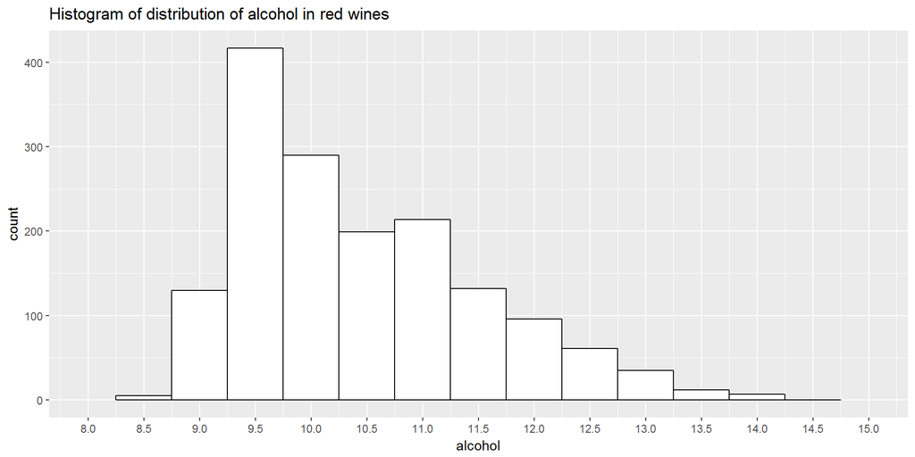

The alcohol content in red wines have a right-skewed distribution with most of the red wines having alcohol content in range from 9-10 % by volume.

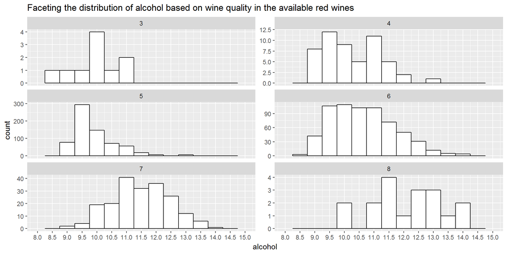

From the faceted distribution of alcohol based on quality it can be observed that usually good quality red wines having quality ratings of **quality 8 and 7** have higher alcohol content than other quality of available red wines.

```
## wine_df$quality: 3
##    Min. 1st Qu.  Median    Mean 3rd Qu.    Max.
##   8.400   9.725   9.925   9.955  10.575  11.000
## --------------------------------------------------------
## wine_df$quality: 4
##    Min. 1st Qu.  Median    Mean 3rd Qu.    Max.
##    9.00    9.60   10.00   10.27   11.00   13.10
## --------------------------------------------------------
## wine_df$quality: 5
##    Min. 1st Qu.  Median    Mean 3rd Qu.    Max.
##     8.5     9.4     9.7     9.9    10.2    14.9
## --------------------------------------------------------
## wine_df$quality: 6
##    Min. 1st Qu.  Median    Mean 3rd Qu.    Max.
##    8.40    9.80   10.50   10.63   11.30   14.00
## --------------------------------------------------------
## wine_df$quality: 7
##    Min. 1st Qu.  Median    Mean 3rd Qu.    Max.
##    9.20   10.80   11.50   11.47   12.10   14.00
## --------------------------------------------------------
## wine_df$quality: 8
##    Min. 1st Qu.  Median    Mean 3rd Qu.    Max.
##    9.80   11.32   12.15   12.09   12.88   14.00
```

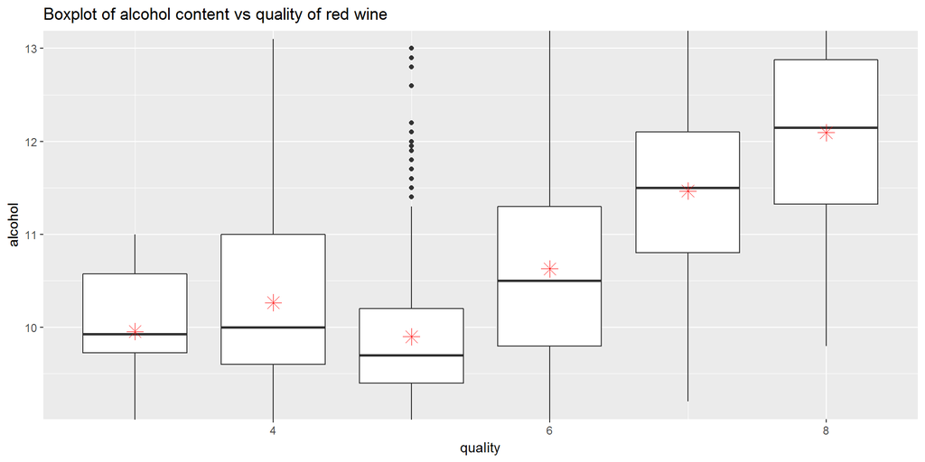

From the statistical summary and boxplot above it can be assumed that high quality of red wines have higher alcohol content % by volume as compared to other lower quality wines. The red point shows the mean value of the alcohol content in percentage by volume.

### Analyzing created variable : Total_acidity

**Description of Total_acidity :** As there are three types of acidity in the red wine so i was just curious to find out the net effect of all acidity on the quality of red wine.

So i created a new variable called **Total_acidity** (measured in g/dm<sup>3</sup>) which is the sum of fixed acidity, volatile acidity and citirc acid.

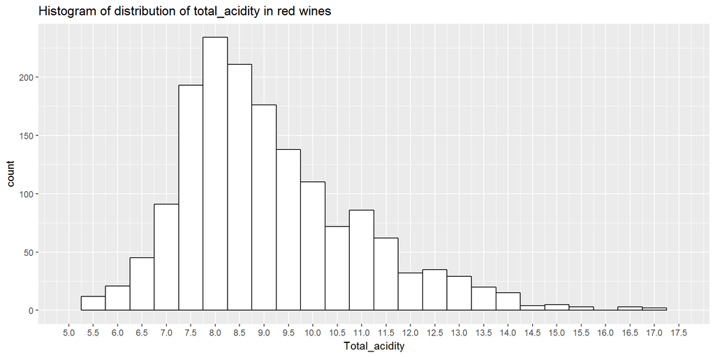

The above histogram has a right-skewed distribution with majority of the red wines having total acidity in the range of 7.5 to 9 g/dm<sup>3</sup>.

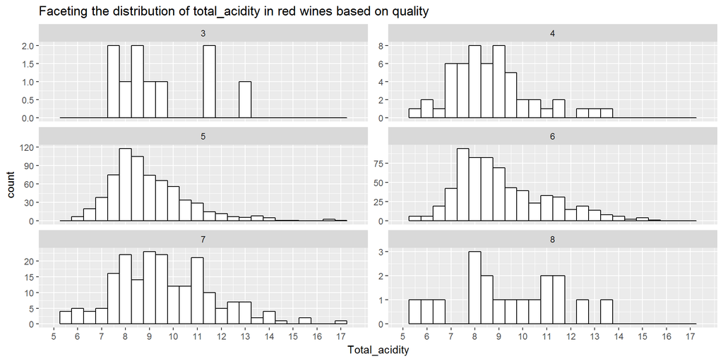

The faceted graph shows the distribution of total acidity in the available red wine for different qualities.Quality 6 and 5 have a right-skewed distribution. And the distibution for better qualilty 7 and 8 have uneven distribution.

```
## wine_df$quality: 3
##    Min. 1st Qu.  Median    Mean 3rd Qu.    Max.
##   7.480   8.101   8.883   9.415  10.780  12.840
## --------------------------------------------------------
## wine_df$quality: 4
##    Min. 1st Qu.  Median    Mean 3rd Qu.    Max.
##   5.270   7.570   8.300   8.647   9.300  13.450
## --------------------------------------------------------
## wine_df$quality: 5
##    Min. 1st Qu.  Median    Mean 3rd Qu.    Max.
##   5.770   7.880   8.600   8.988   9.830  16.910
## --------------------------------------------------------
## wine_df$quality: 6
##    Min. 1st Qu.  Median    Mean 3rd Qu.    Max.
##   5.390   7.710   8.640   9.118  10.186  15.350
## --------------------------------------------------------
## wine_df$quality: 7
##    Min. 1st Qu.  Median    Mean 3rd Qu.    Max.
##   5.320   8.105   9.470   9.651  10.980  17.045
## --------------------------------------------------------
## wine_df$quality: 8
##    Min. 1st Qu.  Median    Mean 3rd Qu.    Max.
##   5.660   7.933   9.095   9.381  11.002  13.630
```

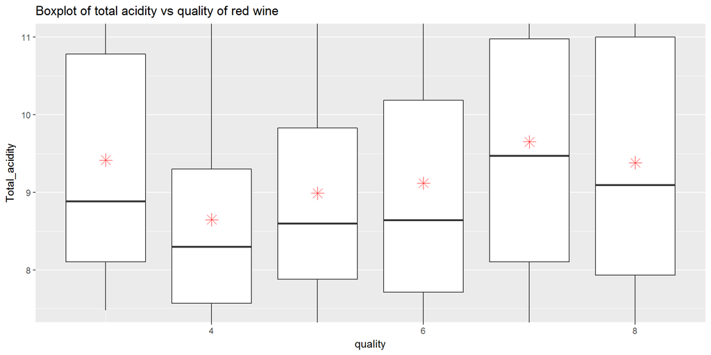

The statistical summary and boxplot of total acidity with respect to quality does not show any type of relation between them. The red point shows the mean value of the total acidity.

### Analyzing created variable : prop_free_so2

**Description of prop_free_so2 :** It is the ratio of free.sulfur.dioxide to total.sulfur.dioxide present in the concerned red wine. As the total.sulfur.dioxide present in the red wine contains both free.sulfur.dioxide and bound.sulfur.dioxide so to determine the proportion in which the free.sulfur.dioxide is used and to check how this ratio affect the quality of red wine we use this variable.

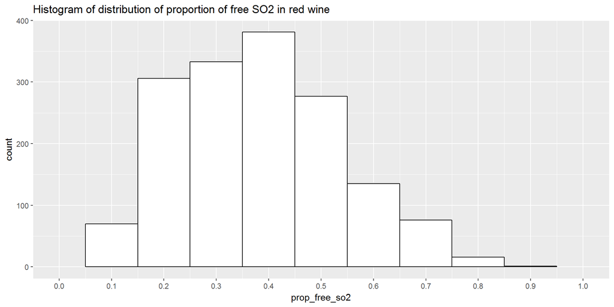

The above histogram shows distribution of proportion of free SO<sup>2</sup> in the red wine and most of the red wines have the proportion usually between 0.1 to 0.5.

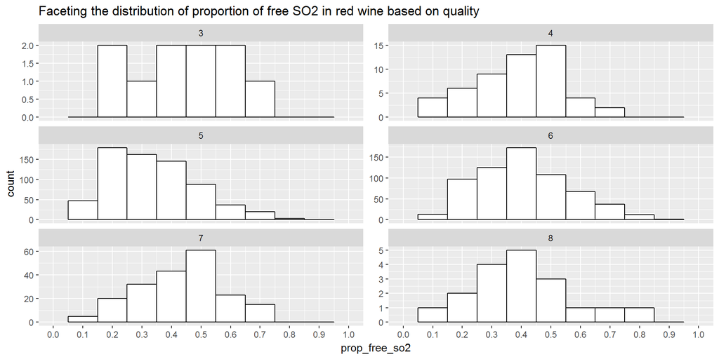

The above faceted distribution shows distribution of proportion of free SO<sup>2</sup> in various qualities of red wine.

```
## wine_df$quality: 3
##    Min. 1st Qu.  Median    Mean 3rd Qu.    Max.
##  0.2128  0.3237  0.4541  0.4366  0.5502  0.7083
## --------------------------------------------------------
## wine_df$quality: 4
##    Min. 1st Qu.  Median    Mean 3rd Qu.    Max.
##  0.0531  0.2727  0.3913  0.3875  0.5000  0.7083
## --------------------------------------------------------
## wine_df$quality: 5
##    Min. 1st Qu.  Median    Mean 3rd Qu.    Max.
## 0.08065 0.23077 0.32394 0.33917 0.42857 0.78261
## --------------------------------------------------------
## wine_df$quality: 6
##    Min. 1st Qu.  Median    Mean 3rd Qu.    Max.
## 0.02273 0.28571 0.40362 0.40962 0.50000 0.85714
## --------------------------------------------------------
## wine_df$quality: 7
##    Min. 1st Qu.  Median    Mean 3rd Qu.    Max.
##  0.1298  0.3333  0.4500  0.4361  0.5357  0.7429
## --------------------------------------------------------
## wine_df$quality: 8
##    Min. 1st Qu.  Median    Mean 3rd Qu.    Max.
##  0.1364  0.3133  0.3823  0.4065  0.4926  0.7556
```

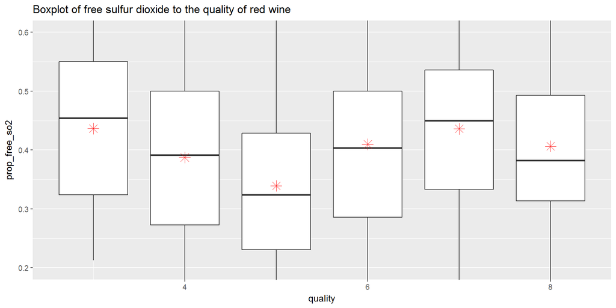

The statistical summary and boxplot gives the median and mean value of proportion of free SO<sup>2</sup> with respect to total sulfur dioxide. The red point shows the mean value of the proportion of free sulfur dioxide.

# Univariate Analysis

### What is the structure of your dataset?

The above dataset consists of 1599 observations and 15 variables.  
Also i added 2 variables to the dataset namely Total_acidity and prop_free_SO2.

### What is/are the main feature(s) of interest in your dataset?

- In the given dataset, 6 qualities of datset are available namely *Quality 3, Quality 4, Quality 5, Quality 6, Quality 7 and Quality 8*.
- Of the available qualities of red wines *quality 5* and *quality 6* are the majority 681 and 638 respectively.

### What other features in the dataset do you think will help support your investigation into your feature(s) of interest?

The following analysis made in the above univariate analysis might help in determining the chemical property which help in influencing the quality of red wines-

- Good quality red wines have lower amounts of volatile acids present in them.
- Citric acid content is higher in good quality wines.
- Amount of residual sugar content is almost same across all qualities of red wine.
- Good quality of red wines have lower density.
- Sulphate content is higher in good quality red wines.
- Alcohol content is higher in good quality red wines.

### Did you create any new variables from existing variables in the dataset?

Yes, i created 2 new variables from the existing variables.

- **Total_acidity :** As there are three types of acidity in the red wine so i was just curious to find out the net effect of all acidity on the quality of red wine. So i created this variable which is the sum of fixed  
  acidity, volatile acidity and citirc acid. (measured in g/dm<sup>3</sup>)
- **prop_free_so2 :** It is the ratio of free.sulfur.dioxide to total.sulfur.dioxide present in the concerned red wine. As the total.sulfur.dioxide present in the red wine contains both free.sulfur.dioxide and bound.sulfur.dioxide so to determine the proportion in which the free.sulfur.dioxide is used and to check how this ratio affect the quality of red wine we use this variable.

# Bivariate Plots Section

In the bivariate analysis, i will start by finding the correlation coefficent between quality and other variables and among the other supporting variables.

**Correlation matrix**

```
##                      fixed.acidity volatile.acidity citric.acid
## fixed.acidity                1.000           -0.256       0.672
## volatile.acidity            -0.256            1.000      -0.552
## citric.acid                  0.672           -0.552       1.000
## residual.sugar               0.115            0.002       0.144
## chlorides                    0.094            0.061       0.204
## free.sulfur.dioxide         -0.154           -0.011      -0.061
## total.sulfur.dioxide        -0.113            0.076       0.036
## density                      0.668            0.022       0.365
## pH                          -0.683            0.235      -0.542
## sulphates                    0.183           -0.261       0.313
## alcohol                     -0.062           -0.202       0.110
## quality                      0.124           -0.391       0.226
## Total_acidity                0.996           -0.204       0.690
## prop_free_so2               -0.131           -0.073      -0.167
##                      residual.sugar chlorides free.sulfur.dioxide
## fixed.acidity                 0.115     0.094              -0.154
## volatile.acidity              0.002     0.061              -0.011
## citric.acid                   0.144     0.204              -0.061
## residual.sugar                1.000     0.056               0.187
## chlorides                     0.056     1.000               0.006
## free.sulfur.dioxide           0.187     0.006               1.000
## total.sulfur.dioxide          0.203     0.047               0.668
## density                       0.355     0.201              -0.022
## pH                           -0.086    -0.265               0.070
## sulphates                     0.006     0.371               0.052
## alcohol                       0.042    -0.221              -0.069
## quality                       0.014    -0.129              -0.051
## Total_acidity                 0.124     0.117              -0.154
## prop_free_so2                -0.071    -0.105               0.327
##                      total.sulfur.dioxide density     pH sulphates alcohol
## fixed.acidity                      -0.113   0.668 -0.683     0.183  -0.062
## volatile.acidity                    0.076   0.022  0.235    -0.261  -0.202
## citric.acid                         0.036   0.365 -0.542     0.313   0.110
## residual.sugar                      0.203   0.355 -0.086     0.006   0.042
## chlorides                           0.047   0.201 -0.265     0.371  -0.221
## free.sulfur.dioxide                 0.668  -0.022  0.070     0.052  -0.069
## total.sulfur.dioxide                1.000   0.071 -0.066     0.043  -0.206
## density                             0.071   1.000 -0.342     0.149  -0.496
## pH                                 -0.066  -0.342  1.000    -0.197   0.206
## sulphates                           0.043   0.149 -0.197     1.000   0.094
## alcohol                            -0.206  -0.496  0.206     0.094   1.000
## quality                            -0.185  -0.175 -0.058     0.251   0.476
## Total_acidity                      -0.096   0.676 -0.683     0.182  -0.067
## prop_free_so2                      -0.371  -0.265  0.185    -0.010   0.246
##                      quality Total_acidity prop_free_so2
## fixed.acidity          0.124         0.996        -0.131
## volatile.acidity      -0.391        -0.204        -0.073
## citric.acid            0.226         0.690        -0.167
## residual.sugar         0.014         0.124        -0.071
## chlorides             -0.129         0.117        -0.105
## free.sulfur.dioxide   -0.051        -0.154         0.327
## total.sulfur.dioxide  -0.185        -0.096        -0.371
## density               -0.175         0.676        -0.265
## pH                    -0.058        -0.683         0.185
## sulphates              0.251         0.182        -0.010
## alcohol                0.476        -0.067         0.246
## quality                1.000         0.104         0.194
## Total_acidity          0.104         1.000        -0.149
## prop_free_so2          0.194        -0.149         1.000
```

**Plotting the Correlation matrix**

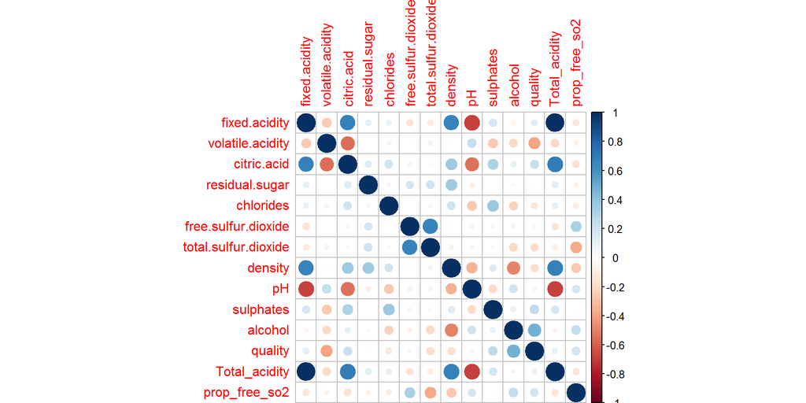

From the correlation matrix plot it can be observed that :

- Fixed acidity is highly correlated citric acid, density and Total acidity. Fixed acidity has high value of negative correlation with pH. And correlation of fixed acidity with quality is very low.
- Volatile acidity is negatively correlated with citric acid and quality.
- Citric acid has high positive correlation with fixed acidity and total acidity.
- Density has highly positively correlated with fixed acidity and total acidity.
- pH has negative correlation with density, fixed, citric and total acidity.
- Quality has negative correlation with density and positive correlation with alcohol.

**Scatterplot matrix**

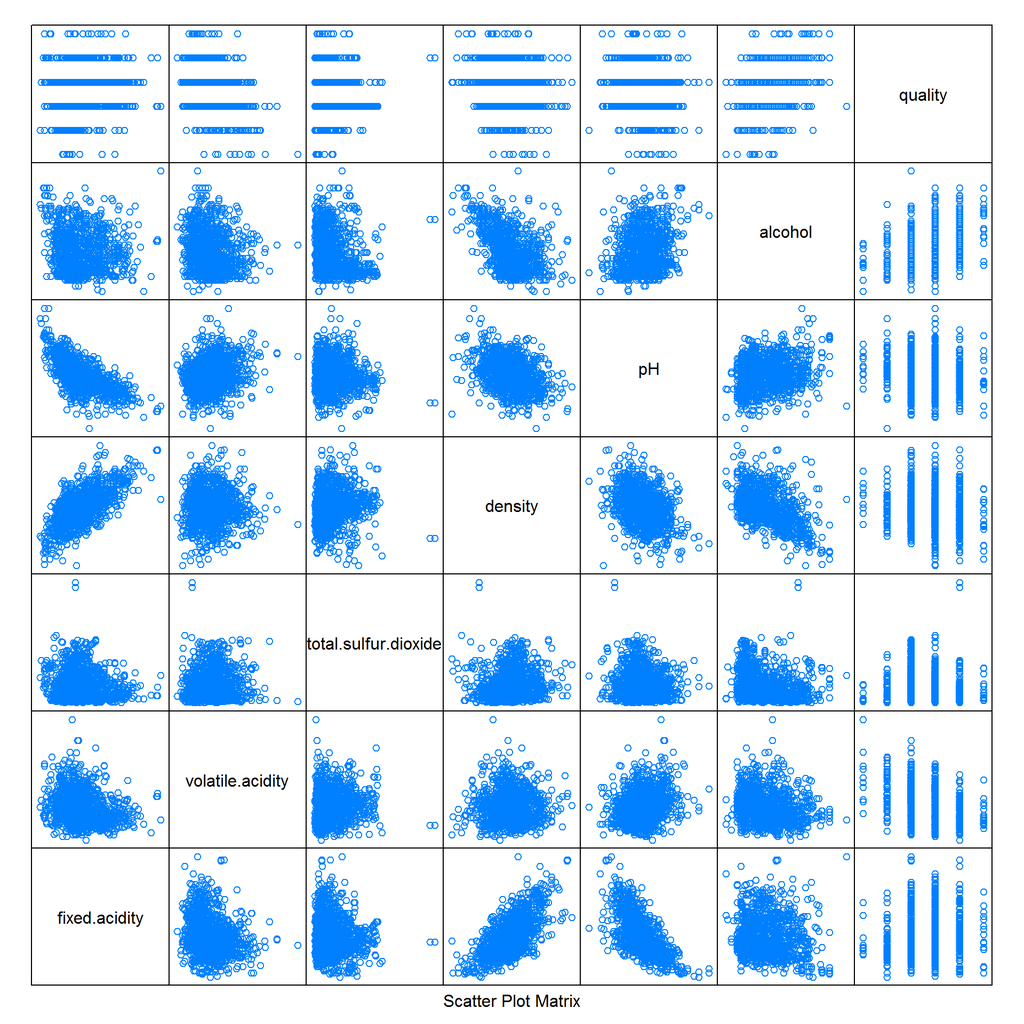

The above scatter plot matrix has been made by selecting the variables from the correlation matrix plot. This graph helps in getting the idea of scatterplot that we will get when plotting different variables in the datset,

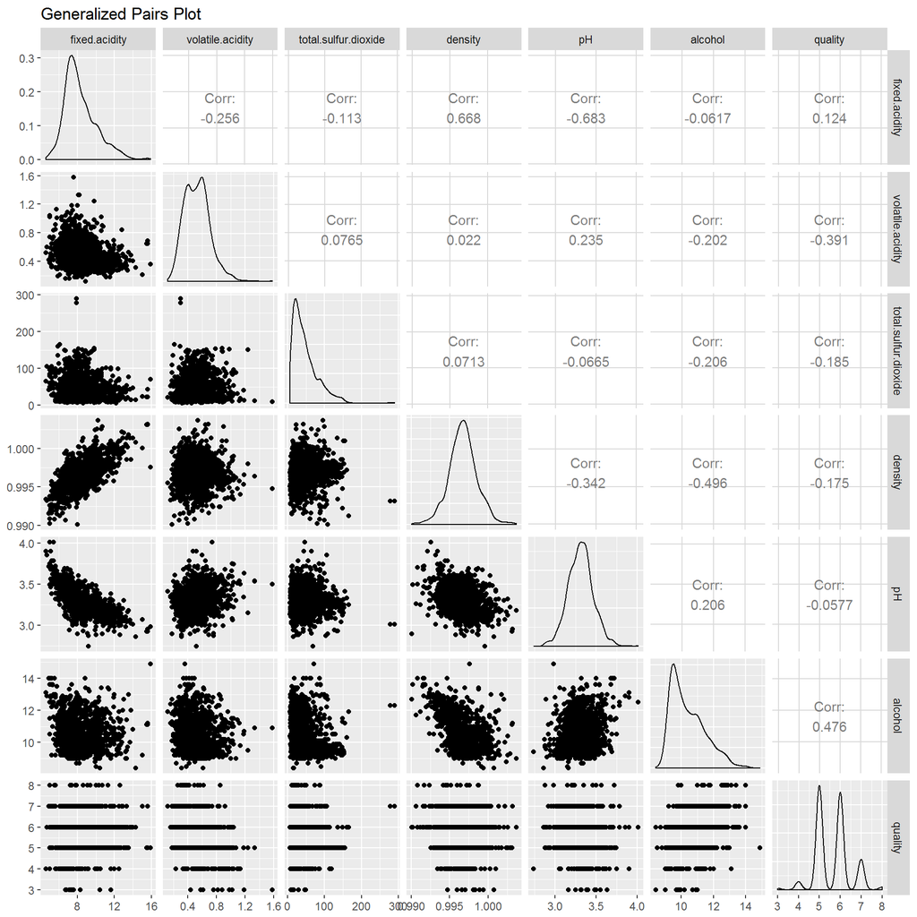

The generalized pairs plot shown above shows the correlation and scatterplot between selected pairs of variables from the correlation and scatterplot matrix shown above. The correlation values between variables are shown in the upper triangular matrix. The diagonal matrix has the pairing between same variables. The lower triangular shows the scatterplot between the pairs of variables. The correlation values and scatterplot between variables helps in understanding the relationship between the variables.

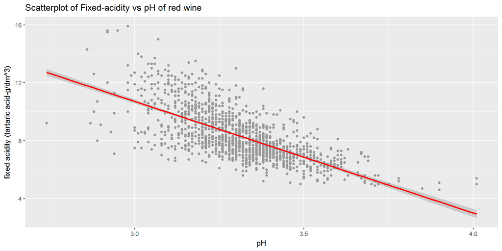

The above graph shows the negative correlation between fixed acidity and pH value of red wine. Also a linear regression line is added to a scatterplot.

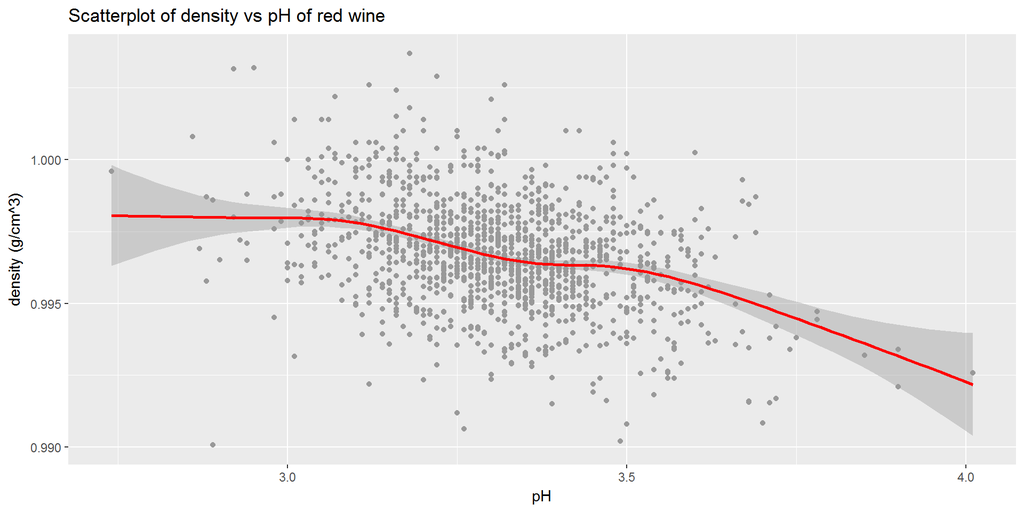

The above graph shows the scatterplot between density and pH of red wine it shows the negative corelation between density and pH. Also the regression line used here is a loess curve.

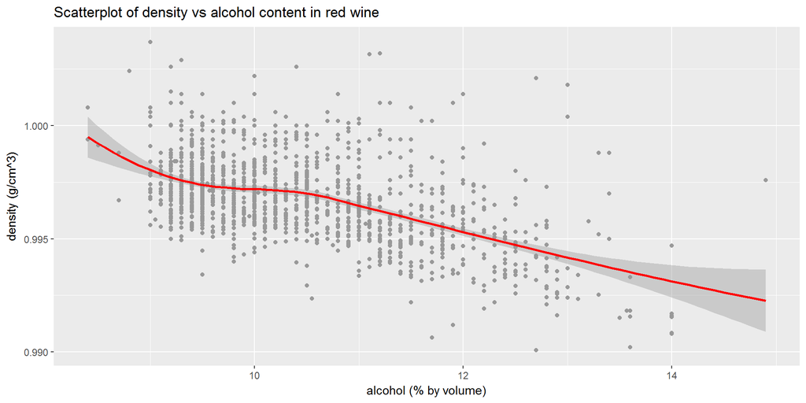

The above graph shows scatterplot of density vs alcohol content in red wine. These parameters are negatively correlated and the negative correlation is shown using a loess curve.

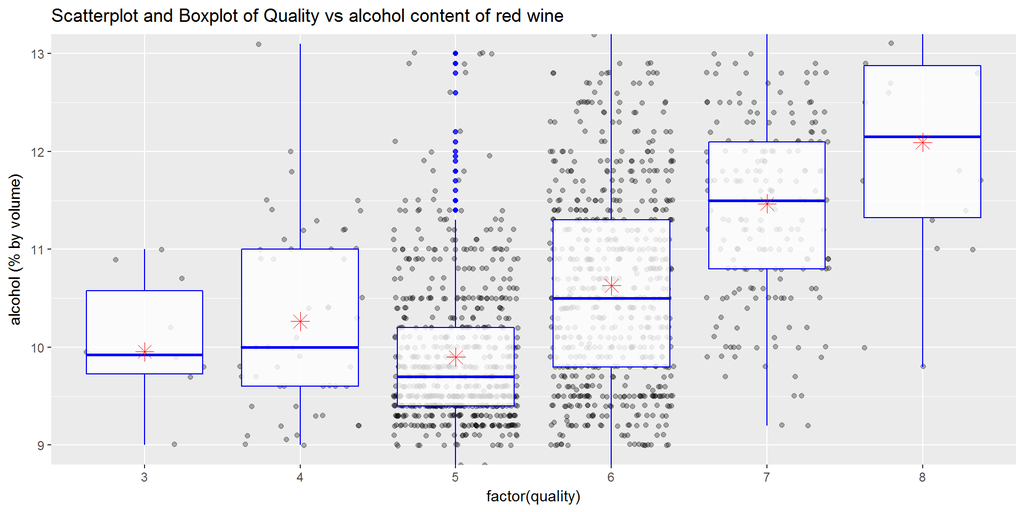

In the univariate analysis, boxplot graph was shown to prove the relation between quality and alcohol content in red wine.

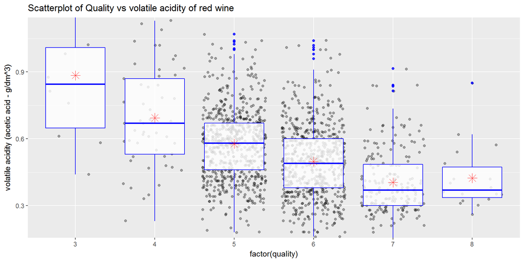

In the univariate analysis, boxplot graph was shown to prove the relation between quality and volatile acidity in red wine.

# Bivariate Analysis

### Talk about some of the relationships you observed in this part of the investigation. How did the feature(s) of interest vary with other features in the dataset?

The bivarite analysis gave an insight into the correlation between quality and other variables with the help of correlation coefficient and scatterplot.It was observed that quality of red wine improves with the decreases in volatile acidity. The alcohol content in red wine also improves the wine quality. From the correlation matrix it was also observed that residual sugar and other parameters don’t have much effect on the quality of red wine.

### Did you observe any interesting relationships between the other features (not the main feature(s) of interest)?

The relationship between pH and fixed/total acidity they have negative correlation i.e., as pH value increases acidity content decreases. Also, pH is negatively correlated with the density of the red wine. And density of the red wine is also having negative correlation with the alcohol content in the red wine. It is also found that citric acid is positively correlated with fixed acidity of red wine but has a negative correlation with volatile acidity.

### What was the strongest relationship you found?

The quality of red wine is highly dependant on volatile acidity and alcohol content of the red wine. The quality and volatile acidity has negative correlation. The quality and alcohol content has a positive correlation between them.

# Multivariate Plots Section

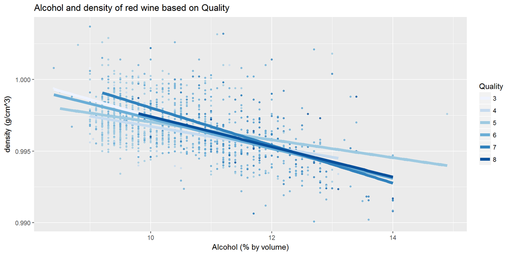

Analyzing the above plot it’s seen that as the quality of red wine improves it’s density decreases and alcohol content also increases as the points seem to move towards the bottom right corner of the graph.

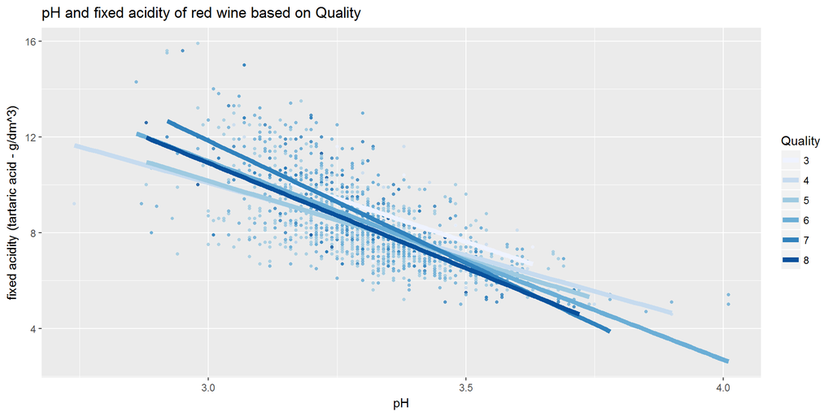

It is observed from the scatterplot that the pH value of wine lies between 3 and 4 . Also for a good quality of red wine pH value must be less than 3.5 as most points are concentrated there. As it is observed from the linear regression lines as pH decreases fixed acidity content also improves.

I also referred the following blog to know more about the pH value of red wines. [Blog on pH of wines](http://winemakersacademy.com/importance-ph-wine-making/)

# Multivariate Analysis

### Talk about some of the relationships you observed in this part of the investigation. Were there features that strengthened each other in terms of looking at your feature(s) of interest?

The relation between fixed acidity and pH by quality strengthens each other. As its known that low pH value implies high acidity so from the graph it is seen that at low pH values fixed acidity value is high. ANd the quality of wine also improves as the above relationship in the wine is satisfied.

### Were there any interesting or surprising interactions between features?

One surprising feature is the relationship between density and alcohol content by quality. It is seen that as the alcohol content decreases the density of the red wine has increased and the quality decreases that is the good quality wines points tend to move towards the right bottom corner of the graph with low density and high alcohol content.

# Final Plots and Summary

### Plot One

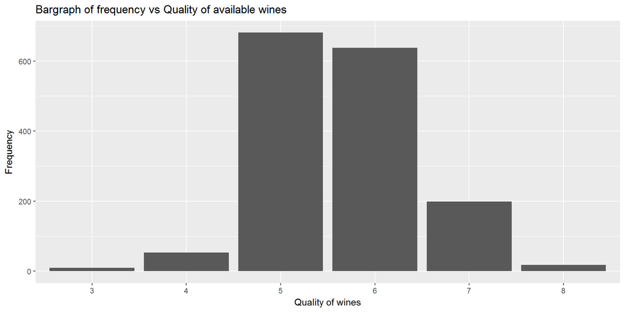

### Description One

It is observed that wines with quality ratings 5and 6 is the most available in the given dataset. Followed by quality 7 and quality 4. Quality 8 followed by quality 3 are the least available. Data below gives the count of each quality of red wine available in the given dataset.

```
##
##   1   2   3   4   5   6   7   8   9  10
##   0   0  10  53 681 638 199  18   0   0
```

### Plot Two

**Plotting the Correlation matrix**

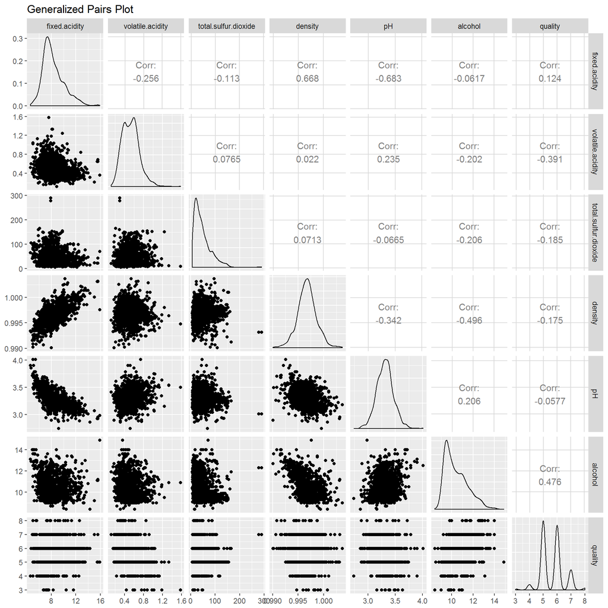

### Description Two

The generalized pairs plot shown above shows the correlation and scatterplot between selected pairs of variables from the correlation and scatterplot matrix shown above. The correlation values between variables are shown in the upper triangular matrix. The diagonal matrix has the pairing between same variables. The lower triangular shows the scatterplot between the pairs of variables. The correlation values and scatterplot between variables helps in understanding the relationship between the variables.

### Plot Three

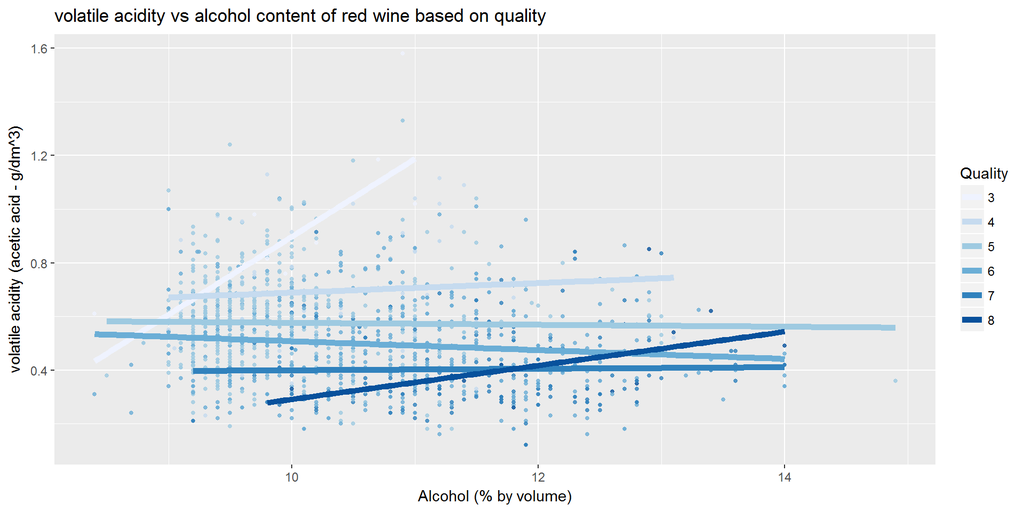

# Reflection

The conclusions drawn by me in this analysis are:

1. In the given dataset for red wine, Quality 5 and quality 6 wines are the most available.
2. Red wines of Quality 1, Quality 2, Quality 9 and Quality 10 are not available.
3. Amount of residual sugar levels (in g/dm<sup>3</sup>) in red wines have no affect on quality of red wine,
4. As pH decreases fixed acidity amount improves.
5. Density of red wine decreases montonically as pH value increases.
6. Density of red wine decreases with increase in alcohol content.
7. Quality of red wine improves as alcohol content increases.
8. Quality of red wine improves as volatile acid’s content decreases.

The analysis could have been performed better if there was more data on other qualities of red wines available. If more data had been availabe results could have been more accurate and new conclusions and inferences could have been made.

It was surprising to see that some chemical parameters such as residual sugar, chlorides, free sulfur dioxide and total sulfur dioxide did not have much affect on the quality of red wine.

For future explorations i can combine the red wine dataset with the dataset for white wine to draw comparisons between them and analyze the differences in their chemical constituents or parameters. Also the data for other qualities of red wine would greatly help in improving this analysis.